# Prediction of Seasonally Adjusted Strengths by Year by Month

This statistical analysis is an attempt to create a regression analysis on monthly seasonal adjustments for North Carolina’s rental values using relavant factors. The output of this regression will be a seasonally adjusted rate based off of an annual calendar that takes into account various factors such as submarket, yearbuilt, rehab, quantity, area, level, market growth, etc.

First, we will load tools useful for a regression analysis.

Next, we will load the dataset.

Now, we will begin by melting the out2 dataset. This means that each month-year column will be pressed into a row with its corresponding rent price as its own column. Simultaneously, seasonally adjusted strength (ASS, lol) will be calculated for each home at a given month

```r
# This might take a minute
# Initialize with an empty list
ob <- list()
for (j in 1:nrow(out2)) {
  # calculate rental values by year and extract the average by year
  vl <- na.omit(t(out2[j,18:ncol(out2)]))
  rwn <- rownames(vl)
  a1 <- data.frame(do.call(rbind,strsplit(rwn,"-")),vl)
  mean_by_year <- aggregate(a1$vl,by = list(a1$X2),mean)

  # Create new variable average and plug in average values per year
  a1$av <- 0
  for(k in 1:nrow(a1)) {
    a1[k,4]<- mean_by_year[mean_by_year[,1] %in% a1$X2[k],2]
  }

  # Divide each rent value by the average to obtain the seasonal strength.
  a1$ass <- vl/a1$av

  # Create lists that have each rental property rent by month by year including its seasonal strength
  newtab <- list()
  for (i in 1:length(rwn)) {
    newtab[[i]] <- cbind(out2[j,1:17],Month = a1$X1[i], Year = a1$X2[i], Rent = vl[i,], ASS = a1$ass[i])
  }
  ob[[j]] <- do.call(rbind,newtab)
}
```

Next is some simple cleab up of dates and names

```r
# Simple Clean_up
rent_table <- do.call(rbind,ob)
rownames(rent_table) <- NULL
# Change months numbers
numMonth <- function(x) { # vectorized math is faster!
  c(jan=1,feb=2,mar=3,apr=4,may=5,jun=6,jul=7,aug=8,sep=9,oct=10,nov=11,dec=12)[tolower(x)]
}
# Change years to long format
numYears <- function(x) {

  now <- as.numeric(substr(strsplit(as.character(Sys.time()),"-")[[1]][1],3,4))
  # Assuming that we do NOT go into the 1800s and the minimum year is 2009
  ifelse(as.numeric(x)<=now,paste(20,x, sep = ""),
         paste(19,x, sep = "")) %>% as.numeric
}
# Use functions (run once, do NOT re-run)
rent_table$Month <- numMonth(rent_table$Month)
rent_table$Year <- numYears(rent_table$Year)
# The table looks as follows
head(rent_table, 10)
```

|  | HomeID | Submarket | Name | Address | City | State | Zip | Phone | YearBuilt | Rehab1 | Rehab2 | Rehab3 | Quantity | AreaPerUnit | Level | Neighborhood | Status | Month | Year | Rent | ASS |
| --- | --- | --- | --- | --- | --- | --- | --- | --- | --- | --- | --- | --- | --- | --- | --- | --- | --- | --- | --- | --- | --- |
| 1 | 1 | Uptown/South End | 1010 Dilworth | 1010 Kenilworth Ave | Charlotte | NC | 28204 | 8553667022 | 2016 | NA | NA | NA | 184 | 785 | 5 | NA | S | 7 | 2016 | 1628 | 1.0082576 |
| 2 | 1 | Uptown/South End | 1010 Dilworth | 1010 Kenilworth Ave | Charlotte | NC | 28204 | 8553667022 | 2016 | NA | NA | NA | 184 | 785 | 5 | NA | S | 8 | 2016 | 1621 | 1.0039224 |
| 3 | 1 | Uptown/South End | 1010 Dilworth | 1010 Kenilworth Ave | Charlotte | NC | 28204 | 8553667022 | 2016 | NA | NA | NA | 184 | 785 | 5 | NA | S | 9 | 2016 | 1625 | 1.0063997 |
| 4 | 1 | Uptown/South End | 1010 Dilworth | 1010 Kenilworth Ave | Charlotte | NC | 28204 | 8553667022 | 2016 | NA | NA | NA | 184 | 785 | 5 | NA | S | 10 | 2016 | 1611 | 0.9977291 |
| 5 | 1 | Uptown/South End | 1010 Dilworth | 1010 Kenilworth Ave | Charlotte | NC | 28204 | 8553667022 | 2016 | NA | NA | NA | 184 | 785 | 5 | NA | S | 11 | 2016 | 1600 | 0.9909166 |
| 6 | 1 | Uptown/South End | 1010 Dilworth | 1010 Kenilworth Ave | Charlotte | NC | 28204 | 8553667022 | 2016 | NA | NA | NA | 184 | 785 | 5 | NA | S | 12 | 2016 | 1603 | 0.9927746 |
| 7 | 1 | Uptown/South End | 1010 Dilworth | 1010 Kenilworth Ave | Charlotte | NC | 28204 | 8553667022 | 2016 | NA | NA | NA | 184 | 785 | 5 | NA | S | 1 | 2017 | 1595 | 1.0278166 |
| 8 | 1 | Uptown/South End | 1010 Dilworth | 1010 Kenilworth Ave | Charlotte | NC | 28204 | 8553667022 | 2016 | NA | NA | NA | 184 | 785 | 5 | NA | S | 2 | 2017 | 1581 | 1.0187950 |
| 9 | 1 | Uptown/South End | 1010 Dilworth | 1010 Kenilworth Ave | Charlotte | NC | 28204 | 8553667022 | 2016 | NA | NA | NA | 184 | 785 | 5 | NA | S | 3 | 2017 | 1548 | 0.9975298 |
| 10 | 1 | Uptown/South End | 1010 Dilworth | 1010 Kenilworth Ave | Charlotte | NC | 28204 | 8553667022 | 2016 | NA | NA | NA | 184 | 785 | 5 | NA | S | 4 | 2017 | 1548 | 0.9975298 |

Now, I will pivot the monthly market growth onto the created table.

```r
# Change out1 types to numeric
out1[,-1] <- apply(out1[,-1],2,as.numeric)
# Create exact columns
short <- rent_table[,c("Month","Year")]
short$Quarter <- 2
short$Quarter[short[,1]<4] <- 1
short$Quarter[short[,1]>9] <- 4
short$Quarter[short[,1]<10&short[,1]>6] <- 3
rent_table$MarketGrowth <- right_join(out1,short,by = c("Year","Quarter"))$RntGrw
head(rent_table,10)
```

|  | HomeID | Submarket | Name | Address | City | State | Zip | Phone | YearBuilt | Rehab1 | Rehab2 | Rehab3 | Quantity | AreaPerUnit | Level | Neighborhood | Status | Month | Year | Rent | ASS | MarketGrowth |
| --- | --- | --- | --- | --- | --- | --- | --- | --- | --- | --- | --- | --- | --- | --- | --- | --- | --- | --- | --- | --- | --- | --- |
| 1 | 1 | Uptown/South End | 1010 Dilworth | 1010 Kenilworth Ave | Charlotte | NC | 28204 | 8553667022 | 2016 | NA | NA | NA | 184 | 785 | 5 | NA | S | 7 | 2016 | 1628 | 1.0082576 | 0.0164 |
| 2 | 1 | Uptown/South End | 1010 Dilworth | 1010 Kenilworth Ave | Charlotte | NC | 28204 | 8553667022 | 2016 | NA | NA | NA | 184 | 785 | 5 | NA | S | 8 | 2016 | 1621 | 1.0039224 | 0.0164 |
| 3 | 1 | Uptown/South End | 1010 Dilworth | 1010 Kenilworth Ave | Charlotte | NC | 28204 | 8553667022 | 2016 | NA | NA | NA | 184 | 785 | 5 | NA | S | 9 | 2016 | 1625 | 1.0063997 | 0.0164 |
| 4 | 1 | Uptown/South End | 1010 Dilworth | 1010 Kenilworth Ave | Charlotte | NC | 28204 | 8553667022 | 2016 | NA | NA | NA | 184 | 785 | 5 | NA | S | 10 | 2016 | 1611 | 0.9977291 | -0.0081 |
| 5 | 1 | Uptown/South End | 1010 Dilworth | 1010 Kenilworth Ave | Charlotte | NC | 28204 | 8553667022 | 2016 | NA | NA | NA | 184 | 785 | 5 | NA | S | 11 | 2016 | 1600 | 0.9909166 | -0.0081 |
| 6 | 1 | Uptown/South End | 1010 Dilworth | 1010 Kenilworth Ave | Charlotte | NC | 28204 | 8553667022 | 2016 | NA | NA | NA | 184 | 785 | 5 | NA | S | 12 | 2016 | 1603 | 0.9927746 | -0.0081 |
| 7 | 1 | Uptown/South End | 1010 Dilworth | 1010 Kenilworth Ave | Charlotte | NC | 28204 | 8553667022 | 2016 | NA | NA | NA | 184 | 785 | 5 | NA | S | 1 | 2017 | 1595 | 1.0278166 | 0.0019 |
| 8 | 1 | Uptown/South End | 1010 Dilworth | 1010 Kenilworth Ave | Charlotte | NC | 28204 | 8553667022 | 2016 | NA | NA | NA | 184 | 785 | 5 | NA | S | 2 | 2017 | 1581 | 1.0187950 | 0.0019 |
| 9 | 1 | Uptown/South End | 1010 Dilworth | 1010 Kenilworth Ave | Charlotte | NC | 28204 | 8553667022 | 2016 | NA | NA | NA | 184 | 785 | 5 | NA | S | 3 | 2017 | 1548 | 0.9975298 | 0.0019 |
| 10 | 1 | Uptown/South End | 1010 Dilworth | 1010 Kenilworth Ave | Charlotte | NC | 28204 | 8553667022 | 2016 | NA | NA | NA | 184 | 785 | 5 | NA | S | 4 | 2017 | 1548 | 0.9975298 | 0.0225 |

Just so you know how this looks like..

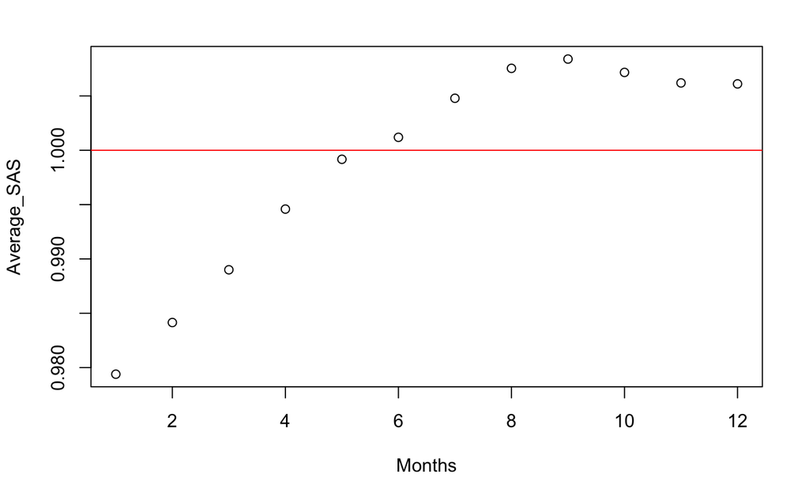

```r
# Each month's Average SAS value.
check <- aggregate(rent_table$ASS,by = list(rent_table$Month), median)
plot(check$Group.1, check$x,ylab = "Average_SAS", xlab = "Months")
abline(h = 1,col = "red")
```

We can do several things from here

1. First, is a bootstrapping test of differences. Is there a robust statistical difference between summer and winter months in terms of seasonal strength?

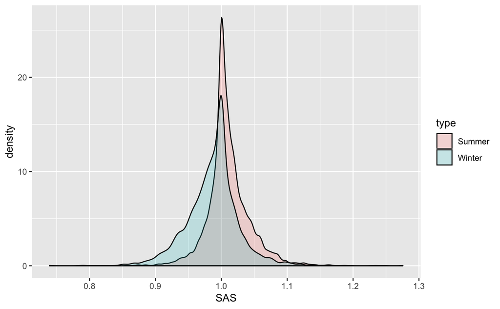

```r
# Grab all summer months, bootstrap them
# Summer Months constitute.. June - Sep (inclusive)
summer <- rent_table[rent_table$Month %in% c(6:9),]$ASS
# Grab all winter months, bootstrap them
# Winter Months constitute.. Dec - Mar
winter <- rent_table[rent_table$Month %in% c(12,1:3),]$ASS
# subtract the average difference. Check if the p-value is below .05
sum <- data.frame(SAS = sample(summer,10000,replace = TRUE))
win <- data.frame(SAS = sample(winter,10000,replace = TRUE))
sum$type <- 'Summer'
win$type <- 'Winter'
SAS_lengths <- rbind(sum, win)
ggplot(SAS_lengths, aes(SAS, fill = type)) + geom_density(alpha = 0.2)
```

```r
# So, if we were to take all these homes only 70% of the time we would see an increase in home values.
# In other words, the summer SAS and winter SAS are not statistically different from each other.
mean(sum$SAS)
```

```
[1] 1.010327
```

```r
mean(win$SAS)
```

```
[1] 0.9874966
```

```r
mean(sum$SAS-win$SAS)
```

```
[1] 0.02283024
```

```r
1-mean(sum$SAS>win$SAS) # So, there is a difference but maybe not a statistical difference.
```

```
[1] 0.309
```

So outright, we can kind of tell that there may not be so much of a “statistical” difference between summer and winter months in terms of seasonal adjustment. p-value is .3 which means.. If we were to pick any summer day and compare it to a winter day,70% of the time, our summer days will be larger in seasonal strengh than our winter days (If I were to pick a random one day in summer and random one day in winter, 70% of the time, summer will be higher than winter. If it was above 95% of the time, then we can say that statistically, we find a sure difference between the two).

If anyone argues with you that you can’t use p-values as percents, tell them they are WRONG! You can use p-values as percents if you BOOTSTRAP the data. You are creating hypothetical simulations of what would actually happen in real-life.

2. Do a Regression

```r
 # removed zip code because it would be collinear with city and hard to read.
Xy_matrix <- rent_table[,c(2,5,6,9,13:15,17:22)]
ass_lm <- lm(log(ASS) ~ Year + Month + MarketGrowth,data =  Xy_matrix)
summary(ass_lm)
```

```
Call:
lm(formula = log(ASS) ~ Year + Month + MarketGrowth, data = Xy_matrix)

Residuals:
     Min       1Q   Median       3Q      Max
-0.30556 -0.01489 -0.00041  0.01681  0.40466

Coefficients:
               Estimate Std. Error t value Pr(>|t|)
(Intercept)  -3.247e-01  9.823e-02  -3.306 0.000947 ***
Year          1.461e-04  4.874e-05   2.998 0.002717 **
Month         3.872e-03  4.549e-05  85.116  < 2e-16 ***
MarketGrowth  4.160e-01  1.135e-02  36.644  < 2e-16 ***
---
Signif. codes:  0 ‘***’ 0.001 ‘**’ 0.01 ‘*’ 0.05 ‘.’ 0.1 ‘ ’ 1

Residual standard error: 0.03438 on 61358 degrees of freedom
Multiple R-squared:  0.1058,    Adjusted R-squared:  0.1057
F-statistic:  2419 on 3 and 61358 DF,  p-value: < 2.2e-16
```

Predictability is low! It is picking up trends, but we are breaking the linearity assumption. Maybe a random Forest may do a bit better.

```r
## library(randomForest)
##
## ass_rf <- randomForest(log(ASS) ~ Year + Month + MarketGrowth,data =  Xy_matrix)
## ass_rf
```

```r
rent_lm <- lm(log(Rent) ~.-ASS, data = Xy_matrix)
summary(rent_lm)
```

```
Call:
lm(formula = log(Rent) ~ . - ASS, data = Xy_matrix)

Residuals:
     Min       1Q   Median       3Q      Max
-0.61235 -0.07239 -0.00489  0.06656  1.15256

Coefficients: (6 not defined because of singularities)
                                        Estimate Std. Error  t value Pr(>|t|)
(Intercept)                           -9.158e+01  3.575e-01 -256.195  < 2e-16 ***
SubmarketConcord/Kannapolis/Salisbury -3.862e-01  2.346e-02  -16.465  < 2e-16 ***
SubmarketEast Charlotte               -1.122e-01  3.029e-03  -37.023  < 2e-16 ***
SubmarketFar East Charlotte/Mint Hill -1.779e-01  3.563e-03  -49.934  < 2e-16 ***
SubmarketGaston County                -2.195e-01  2.431e-02   -9.028  < 2e-16 ***
SubmarketHuntersville/Cornelius       -1.327e-01  2.330e-02   -5.694 1.25e-08 ***
SubmarketMatthews/Southeast Charlotte -3.715e-02  4.289e-03   -8.661  < 2e-16 ***
SubmarketMooresville/Statesville      -3.906e-01  2.357e-02  -16.575  < 2e-16 ***
SubmarketMyers Park                    1.042e-01  3.272e-03   31.830  < 2e-16 ***
SubmarketNorth Charlotte              -1.071e-01  3.111e-03  -34.421  < 2e-16 ***
SubmarketRock Hill/Fort Mill          -3.461e-01  3.825e-02   -9.047  < 2e-16 ***
SubmarketSouth Charlotte              -3.143e-02  3.119e-03  -10.076  < 2e-16 ***
SubmarketSouthwest Charlotte          -1.224e-01  2.953e-03  -41.442  < 2e-16 ***
SubmarketUNC Charlotte                -1.552e-01  2.996e-03  -51.818  < 2e-16 ***
SubmarketUptown/South End              2.200e-01  3.366e-03   65.367  < 2e-16 ***
CityCharlotte                         -3.726e-02  2.297e-02   -1.622  0.10479
CityClover                             3.477e-02  3.172e-02    1.096  0.27298
CityConcord                            1.098e-01  4.800e-03   22.879  < 2e-16 ***
CityCornelius                          3.062e-03  5.245e-03    0.584  0.55929
CityCramerton                         -9.362e-02  1.353e-02   -6.917 4.67e-12 ***
CityDallas                            -1.881e-01  4.381e-02   -4.294 1.75e-05 ***
CityDavidson                           3.624e-02  7.175e-03    5.051 4.42e-07 ***
CityDenver                             1.526e-01  1.543e-02    9.891  < 2e-16 ***
CityFort Mill                          1.913e-01  3.070e-02    6.232 4.63e-10 ***
CityGastonia                          -4.845e-02  8.118e-03   -5.969 2.41e-09 ***
CityHuntersville                              NA         NA       NA       NA
CityIndian Land                        1.955e-01  3.972e-02    4.921 8.64e-07 ***
CityIndian Trail                      -4.306e-02  2.469e-02   -1.744  0.08120 .
CityKannapolis                         1.051e-01  6.669e-03   15.765  < 2e-16 ***
CityLake Wylie                         3.870e-02  3.203e-02    1.208  0.22687
CityLincolnton                        -3.270e-01  1.282e-02  -25.519  < 2e-16 ***
```

[output cut: 13 more lines]

```
Quantity                               1.139e-04  4.991e-06   22.821  < 2e-16 ***
AreaPerUnit                            6.577e-04  3.596e-06  182.901  < 2e-16 ***
Level                                  1.173e-02  2.024e-04   57.958  < 2e-16 ***
StatusR                               -1.098e-01  8.838e-03  -12.426  < 2e-16 ***
StatusS                               -8.404e-02  8.246e-03  -10.191  < 2e-16 ***
StatusUC/LU                           -1.854e-01  2.172e-02   -8.538  < 2e-16 ***
Month                                  4.196e-03  1.615e-04   25.985  < 2e-16 ***
Year                                   4.140e-02  1.764e-04  234.611  < 2e-16 ***
MarketGrowth                           3.681e-01  4.028e-02    9.139  < 2e-16 ***
---
Signif. codes:  0 ‘***’ 0.001 ‘**’ 0.01 ‘*’ 0.05 ‘.’ 0.1 ‘ ’ 1

Residual standard error: 0.122 on 61315 degrees of freedom
Multiple R-squared:  0.8318,    Adjusted R-squared:  0.8317
F-statistic:  6591 on 46 and 61315 DF,  p-value: < 2.2e-16
```

So, using regression models, we realize that it is difficult to predict percentage SAS values. It isn’t that difficult to calculate rent price by location but SAS seems to normalize out the fact that it is in a certain area. Also, because a regression is linear in nature, variates such as Market Growth and SAS tend to be best predicted using a seasonal model.

3. Predict SAS for each month using Market Growth

After doing a regression, it seemed like the most important variables in predicting seasonally adjusted strength were: market growth, month, and year. This is probably because the data was breaking linearity assumptions due to seasonal trends.

Assuming that I have already done a regression, I will now create an ARIMAX time series prediction. This time series predicts the percentage away from the average for this year (2020).

```r
# Adjust dataset
time_series <- select(rent_table,MarketGrowth,Month,Year,ASS)
sas_table <- aggregate(time_series$ASS,by = list(time_series$Month,time_series$Year), mean)
mkt_table <- aggregate(time_series$MarketGrowth, by = list(time_series$Month,time_series$Year),mean)
t_series <- cbind(sas_table,"Market_Growth" = mkt_table$x)
colnames(t_series) <- c("Month","Year","ASS","Market_Growth")
```

Let’s use an ARIMAX to predict Market Growth and SAS.

First, I will identify if there is a pattern in market growth. If there is a certain pattern, it may or may not help depending on how SAS increases and decreases.

```r
colores <-  c(rep("steel blue",3),rep("forest green",3), rep("red",3), rep("orange",3))
plot(t_series$Market_Growth, type = "b", col =colores)
abline(h = ".01", col = "black",lty = 2)
```

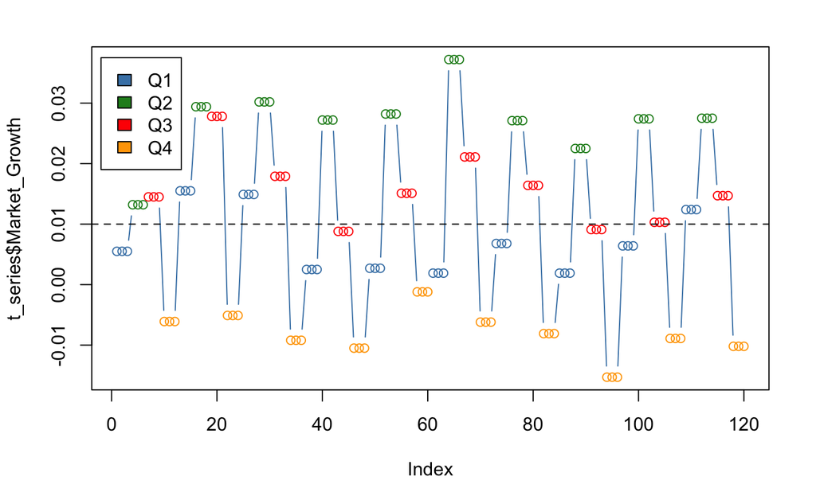

```r
legend(-2,.0375,c("Q1","Q2","Q3","Q4"),c("steel blue","forest green","red","orange"))
```

Similarly, I will take a look at SAS. It looks almost like the market growth is the *mathematical first derivative* of what SAS will act like. This means that the values could potentially help.

```r
plot(t_series$ASS, type = "b", col =colores)
abline(h = ".01", col = "black",lty = 2)
```

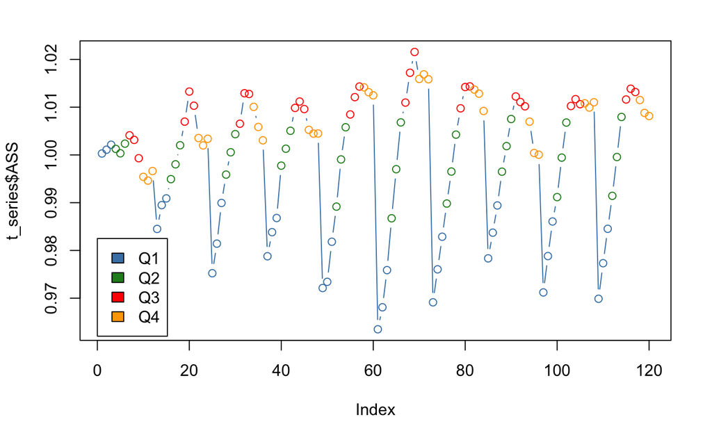

```r
legend(0,.9825,c("Q1","Q2","Q3","Q4"),c("steel blue","forest green","red","orange"))
```

Use ARIMA.

```r
# Using Autoregressive time series, model SAS using market growth as variable
check <- auto.arima(t_series$ASS,xreg = as.matrix(select(t_series,Market_Growth)))
# Using Autoregressive time series, PREDICT Market Growth (no variables) for future prediction.
mkt_grth <- auto.arima(t_series$Market_Growth)
ran <- FALSE
mkp <- ifelse(ran,sample(t_series$Market_Growth,12),predict(mkt_grth,n.ahead = 12)$pred)
arima_mg <- data.frame(Market_Growth = predict(mkt_grth,n.ahead = 12)$pred)
# Predict using the random Market Growth Sample dataset
pp <- predict(check,n.ahead = 12, newxreg = mkp)
plot(c(t_series$ASS,pp$pred[1]),type = "b", xlim = c(60,135),
     ylim = c(0.95,1.05) ,xlab = "Months",ylab = "SAS", main = "SAS Prediction Considering Market Growth")
lines(pp$pred,col = "red",type = "b")
```

```r
lines(pp$pred + (pp$se*1.96), col = "blue",type = "l", lty = 2)
lines(pp$pred - (pp$se*1.96), col = "blue",type = "l", lty = 2)
```

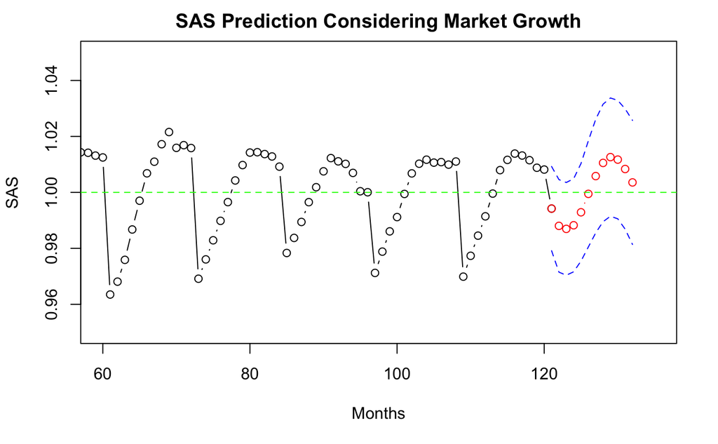

```r
abline(h = 1, col = "green", lty = 2)
```

If we want to add further on this model, we can add other factors to strengthen predictability.

You’ll also notice something amazing about SAS. You CANNOT compare seasonally adjusted strength values from year to year. They are summary values that are amalgamated from every 12-month cycle.